# SQ 018

## Shared Qs (018)

#### Question

1. A geometric sequence has a first term 0.7 and a common ratio 1.1. Find the sum of the first 21 terms.

   The tolerance is $\pm 0.01$.

   (*We call the **sum** of a geometric sequence a [geometric series](https://en.wikipedia.org/wiki/Geometric_series).*)

#### Solution

#### Question

2. A geometric sequence has a first term 50 and a common ratio 0.83. Find the sum of the first 20 terms.

   The tolerance is $\pm 0.01$.

   (*We call the **sum** of a geometric sequence a [geometric series](https://en.wikipedia.org/wiki/Geometric_series).*)

#### Solution

#### Question

3. A geometric sequence has a first term 90 and a common ratio 1.16. Find the sum of the first 25 terms.

   The tolerance is $\pm 0.01$.

   (*We call the **sum** of a geometric sequence a [geometric series](https://en.wikipedia.org/wiki/Geometric_series).*)

#### Solution

#### Question

4. A geometric sequence has a first term 300 and a common ratio 0.8. Find the sum of the first 15 terms.

   The tolerance is $\pm 0.01$.

   (*We call the **sum** of a geometric sequence a [geometric series](https://en.wikipedia.org/wiki/Geometric_series).*)

#### Solution

#### Question

5. A geometric sequence has a first term 0.3 and a common ratio 0.86. Find the sum of the first 13 terms.

   The tolerance is $\pm 0.01$.

   (*We call the **sum** of a geometric sequence a [geometric series](https://en.wikipedia.org/wiki/Geometric_series).*)

#### Solution

#### Question

6. A geometric sequence has a first term 0.4 and a common ratio 1.19. Find the sum of the first 15 terms.

   The tolerance is $\pm 0.01$.

   (*We call the **sum** of a geometric sequence a [geometric series](https://en.wikipedia.org/wiki/Geometric_series).*)

#### Solution

#### Question

7. A geometric sequence has a first term 0.6 and a common ratio 0.89. Find the sum of the first 29 terms.

   The tolerance is $\pm 0.01$.

   (*We call the **sum** of a geometric sequence a [geometric series](https://en.wikipedia.org/wiki/Geometric_series).*)

#### Solution

#### Question

8. A geometric sequence has a first term 800 and a common ratio 1.01. Find the sum of the first 10 terms.

   The tolerance is $\pm 0.01$.

   (*We call the **sum** of a geometric sequence a [geometric series](https://en.wikipedia.org/wiki/Geometric_series).*)

#### Solution

#### Question

9. A geometric sequence has a first term 0.6 and a common ratio 0.94. Find the sum of the first 11 terms.

   The tolerance is $\pm 0.01$.

   (*We call the **sum** of a geometric sequence a [geometric series](https://en.wikipedia.org/wiki/Geometric_series).*)

#### Solution

#### Question

10. A geometric sequence has a first term 0.8 and a common ratio 0.82. Find the sum of the first 17 terms.

    The tolerance is $\pm 0.01$.

    (*We call the **sum** of a geometric sequence a [geometric series](https://en.wikipedia.org/wiki/Geometric_series).*)

#### Solution

#### Question

11. An infinite geometric series converges if and only if $|r|<1$. A convergent series will approach a finite value as more terms are added; a divergent series will approach infinity. **Is the following geometric series convergent?**

    $$60~-~48~+~38.4~-~\ldots$$
    1. Yes, the series converges.
    2. No, the series diverges.

#### Solution

#### Question

12. An infinite geometric series converges if and only if $|r|<1$. A convergent series will approach a finite value as more terms are added; a divergent series will approach infinity. **Is the following geometric series convergent?**

    $$-50~-~56.5~-~63.845~-~\ldots$$
    1. Yes, the series converges.
    2. No, the series diverges.

#### Solution

#### Question

13. An infinite geometric series converges if and only if $|r|<1$. A convergent series will approach a finite value as more terms are added; a divergent series will approach infinity. **Is the following geometric series convergent?**

    $$400~+~436~+~475.24~+~\ldots$$
    1. Yes, the series converges.
    2. No, the series diverges.

#### Solution

#### Question

14. An infinite geometric series converges if and only if $|r|<1$. A convergent series will approach a finite value as more terms are added; a divergent series will approach infinity. **Is the following geometric series convergent?**

    $$-0.4~-~0.36~-~0.324~-~\ldots$$
    1. Yes, the series converges.
    2. No, the series diverges.

#### Solution

#### Question

15. An infinite geometric series converges if and only if $|r|<1$. A convergent series will approach a finite value as more terms are added; a divergent series will approach infinity. **Is the following geometric series convergent?**

    $$-20~-~18.2~-~16.562~-~\ldots$$
    1. Yes, the series converges.
    2. No, the series diverges.

#### Solution

#### Question

16. An infinite geometric series converges if and only if $|r|<1$. A convergent series will approach a finite value as more terms are added; a divergent series will approach infinity. **Is the following geometric series convergent?**

    $$0.7~-~0.644~+~0.59248~-~\ldots$$
    1. Yes, the series converges.
    2. No, the series diverges.

#### Solution

#### Question

17. An infinite geometric series converges if and only if $|r|<1$. A convergent series will approach a finite value as more terms are added; a divergent series will approach infinity. **Is the following geometric series convergent?**

    $$600~-~648~+~699.84~-~\ldots$$
    1. Yes, the series converges.
    2. No, the series diverges.

#### Solution

#### Question

18. An infinite geometric series converges if and only if $|r|<1$. A convergent series will approach a finite value as more terms are added; a divergent series will approach infinity. **Is the following geometric series convergent?**

    $$-70~+~83.3~-~99.127~+~\ldots$$
    1. Yes, the series converges.
    2. No, the series diverges.

#### Solution

#### Question

19. An infinite geometric series converges if and only if $|r|<1$. A convergent series will approach a finite value as more terms are added; a divergent series will approach infinity. **Is the following geometric series convergent?**

    $$8~-~9.36~+~10.9512~-~\ldots$$
    1. Yes, the series converges.
    2. No, the series diverges.

#### Solution

#### Question

20. An infinite geometric series converges if and only if $|r|<1$. A convergent series will approach a finite value as more terms are added; a divergent series will approach infinity. **Is the following geometric series convergent?**

    $$-0.9~+~0.963~-~1.03041~+~\ldots$$
    1. Yes, the series converges.
    2. No, the series diverges.

#### Solution

#### Question

21. A convergent infinite geometric series has a finite sum. First, remember the geometric series formula:

    $$S_n = \frac{a(1-r^n)}{1-r}$$

    If $|r|<1$, then $\lim\limits_{n\to\infty}1-r^n = 1$, because repeated multiplication of a [proper fraction](https://en.wikipedia.org/wiki/Fraction#Proper_and_improper_fractions) creates numbers closer and closer to 0.

    So, if $|r|<1$, then

    $$S_{\infty} ~=~ \frac{a}{1-r}$$

    Find the sum of the following geometric series (with infinitely many terms).

    $$-800~+~720~-~648~+~\ldots$$

#### Solution

#### Question

22. A convergent infinite geometric series has a finite sum. First, remember the geometric series formula:

    $$S_n = \frac{a(1-r^n)}{1-r}$$

    If $|r|<1$, then $\lim\limits_{n\to\infty}1-r^n = 1$, because repeated multiplication of a [proper fraction](https://en.wikipedia.org/wiki/Fraction#Proper_and_improper_fractions) creates numbers closer and closer to 0.

    So, if $|r|<1$, then

    $$S_{\infty} ~=~ \frac{a}{1-r}$$

    Find the sum of the following geometric series (with infinitely many terms).

    $$-300~+~339~-~383.07~+~\ldots$$

#### Solution

#### Question

23. A convergent infinite geometric series has a finite sum. First, remember the geometric series formula:

    $$S_n = \frac{a(1-r^n)}{1-r}$$

    If $|r|<1$, then $\lim\limits_{n\to\infty}1-r^n = 1$, because repeated multiplication of a [proper fraction](https://en.wikipedia.org/wiki/Fraction#Proper_and_improper_fractions) creates numbers closer and closer to 0.

    So, if $|r|<1$, then

    $$S_{\infty} ~=~ \frac{a}{1-r}$$

    Find the sum of the following geometric series (with infinitely many terms).

    $$6~-~6.66~+~7.3926~-~\ldots$$

#### Solution

#### Question

24. A convergent infinite geometric series has a finite sum. First, remember the geometric series formula:

    $$S_n = \frac{a(1-r^n)}{1-r}$$

    If $|r|<1$, then $\lim\limits_{n\to\infty}1-r^n = 1$, because repeated multiplication of a [proper fraction](https://en.wikipedia.org/wiki/Fraction#Proper_and_improper_fractions) creates numbers closer and closer to 0.

    So, if $|r|<1$, then

    $$S_{\infty} ~=~ \frac{a}{1-r}$$

    Find the sum of the following geometric series (with infinitely many terms).

    $$20~-~22~+~24.2~-~\ldots$$

#### Solution

#### Question

25. A convergent infinite geometric series has a finite sum. First, remember the geometric series formula:

    $$S_n = \frac{a(1-r^n)}{1-r}$$

    If $|r|<1$, then $\lim\limits_{n\to\infty}1-r^n = 1$, because repeated multiplication of a [proper fraction](https://en.wikipedia.org/wiki/Fraction#Proper_and_improper_fractions) creates numbers closer and closer to 0.

    So, if $|r|<1$, then

    $$S_{\infty} ~=~ \frac{a}{1-r}$$

    Find the sum of the following geometric series (with infinitely many terms).

    $$-600~+~696~-~807.36~+~\ldots$$

#### Solution

#### Question

26. A convergent infinite geometric series has a finite sum. First, remember the geometric series formula:

    $$S_n = \frac{a(1-r^n)}{1-r}$$

    If $|r|<1$, then $\lim\limits_{n\to\infty}1-r^n = 1$, because repeated multiplication of a [proper fraction](https://en.wikipedia.org/wiki/Fraction#Proper_and_improper_fractions) creates numbers closer and closer to 0.

    So, if $|r|<1$, then

    $$S_{\infty} ~=~ \frac{a}{1-r}$$

    Find the sum of the following geometric series (with infinitely many terms).

    $$-40~-~38.4~-~36.864~-~\ldots$$

#### Solution

#### Question

27. A convergent infinite geometric series has a finite sum. First, remember the geometric series formula:

    $$S_n = \frac{a(1-r^n)}{1-r}$$

    If $|r|<1$, then $\lim\limits_{n\to\infty}1-r^n = 1$, because repeated multiplication of a [proper fraction](https://en.wikipedia.org/wiki/Fraction#Proper_and_improper_fractions) creates numbers closer and closer to 0.

    So, if $|r|<1$, then

    $$S_{\infty} ~=~ \frac{a}{1-r}$$

    Find the sum of the following geometric series (with infinitely many terms).

    $$0.6~-~0.534~+~0.47526~-~\ldots$$

#### Solution

#### Question

28. A convergent infinite geometric series has a finite sum. First, remember the geometric series formula:

    $$S_n = \frac{a(1-r^n)}{1-r}$$

    If $|r|<1$, then $\lim\limits_{n\to\infty}1-r^n = 1$, because repeated multiplication of a [proper fraction](https://en.wikipedia.org/wiki/Fraction#Proper_and_improper_fractions) creates numbers closer and closer to 0.

    So, if $|r|<1$, then

    $$S_{\infty} ~=~ \frac{a}{1-r}$$

    Find the sum of the following geometric series (with infinitely many terms).

    $$-5~-~5.2~-~5.408~-~\ldots$$

#### Solution

#### Question

29. A convergent infinite geometric series has a finite sum. First, remember the geometric series formula:

    $$S_n = \frac{a(1-r^n)}{1-r}$$

    If $|r|<1$, then $\lim\limits_{n\to\infty}1-r^n = 1$, because repeated multiplication of a [proper fraction](https://en.wikipedia.org/wiki/Fraction#Proper_and_improper_fractions) creates numbers closer and closer to 0.

    So, if $|r|<1$, then

    $$S_{\infty} ~=~ \frac{a}{1-r}$$

    Find the sum of the following geometric series (with infinitely many terms).

    $$-0.7~-~0.798~-~0.90972~-~\ldots$$

#### Solution

#### Question

30. A convergent infinite geometric series has a finite sum. First, remember the geometric series formula:

    $$S_n = \frac{a(1-r^n)}{1-r}$$

    If $|r|<1$, then $\lim\limits_{n\to\infty}1-r^n = 1$, because repeated multiplication of a [proper fraction](https://en.wikipedia.org/wiki/Fraction#Proper_and_improper_fractions) creates numbers closer and closer to 0.

    So, if $|r|<1$, then

    $$S_{\infty} ~=~ \frac{a}{1-r}$$

    Find the sum of the following geometric series (with infinitely many terms).

    $$900~-~999~+~1108.89~-~\ldots$$

#### Solution

#### Question

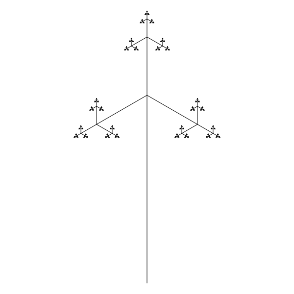

31. The fractal above is composed of many line segments. The largest segment is 1 unit long. There are then 3 segments, each with a length of $k = 0.31$. To continue the pattern, there are 9 segments with length $k^2=0.0961$. Then, 27 segments with length $k^3$ and 81 with length $k^4$ etc…

    How much total length is needed to construct this fractal (with infinite depths of recursion)? Find the sum of all the lengths.

    In other words, if $k=0.31$, evaluate the following:

    $$\sum_{i=0}^\infty(3k)^{i} ~=~ 1 + 3k + 9k^2 + 27k^3 + \ldots ~=~ ~?$$

    The tolerance is $\pm 0.01$.

#### Solution

#### Question

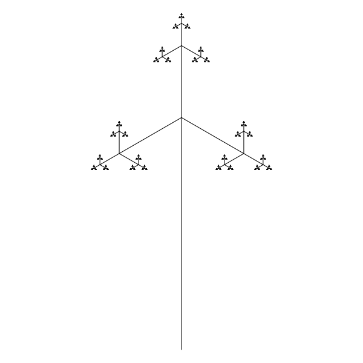

32. The fractal above is composed of many line segments. The largest segment is 1 unit long. There are then 3 segments, each with a length of $k = 0.31$. To continue the pattern, there are 9 segments with length $k^2=0.0961$. Then, 27 segments with length $k^3$ and 81 with length $k^4$ etc…

    How much total length is needed to construct this fractal (with infinite depths of recursion)? Find the sum of all the lengths.

    In other words, if $k=0.31$, evaluate the following:

    $$\sum_{i=0}^\infty(3k)^{i} ~=~ 1 + 3k + 9k^2 + 27k^3 + \ldots ~=~ ~?$$

    The tolerance is $\pm 0.01$.

#### Solution

#### Question

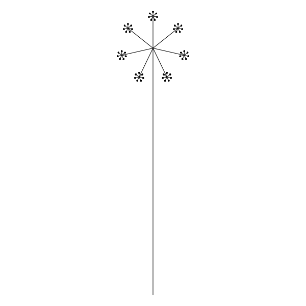

33. The fractal above is composed of many line segments. The largest segment is 1 unit long. There are then 7 segments, each with a length of $k = 0.13$. To continue the pattern, there are 49 segments with length $k^2=0.0169$. Then, 343 segments with length $k^3$ and 2401 with length $k^4$ etc…

    How much total length is needed to construct this fractal (with infinite depths of recursion)? Find the sum of all the lengths.

    In other words, if $k=0.13$, evaluate the following:

    $$\sum_{i=0}^\infty(7k)^{i} ~=~ 1 + 7k + 49k^2 + 343k^3 + \ldots ~=~ ~?$$

    The tolerance is $\pm 0.01$.

#### Solution

#### Question

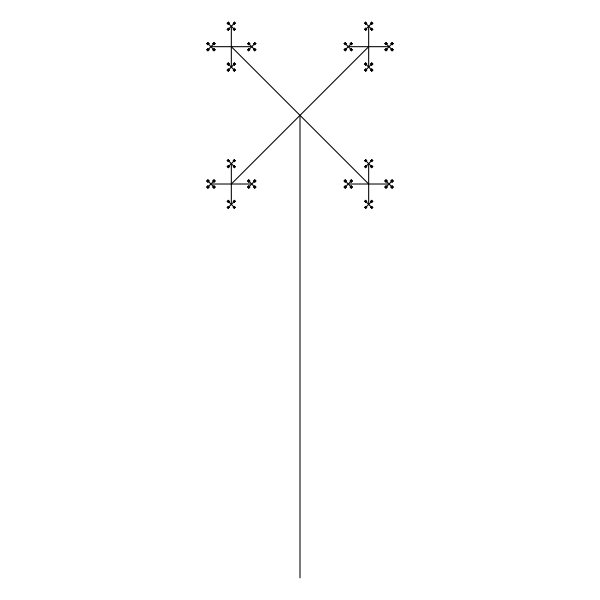

34. The fractal above is composed of many line segments. The largest segment is 1 unit long. There are then 4 segments, each with a length of $k = 0.21$. To continue the pattern, there are 16 segments with length $k^2=0.0441$. Then, 64 segments with length $k^3$ and 256 with length $k^4$ etc…

    How much total length is needed to construct this fractal (with infinite depths of recursion)? Find the sum of all the lengths.

    In other words, if $k=0.21$, evaluate the following:

    $$\sum_{i=0}^\infty(4k)^{i} ~=~ 1 + 4k + 16k^2 + 64k^3 + \ldots ~=~ ~?$$

    The tolerance is $\pm 0.01$.

#### Solution

#### Question

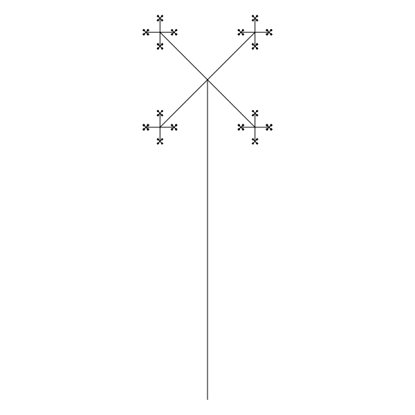

35. The fractal above is composed of many line segments. The largest segment is 1 unit long. There are then 4 segments, each with a length of $k = 0.21$. To continue the pattern, there are 16 segments with length $k^2=0.0441$. Then, 64 segments with length $k^3$ and 256 with length $k^4$ etc…

    How much total length is needed to construct this fractal (with infinite depths of recursion)? Find the sum of all the lengths.

    In other words, if $k=0.21$, evaluate the following:

    $$\sum_{i=0}^\infty(4k)^{i} ~=~ 1 + 4k + 16k^2 + 64k^3 + \ldots ~=~ ~?$$

    The tolerance is $\pm 0.01$.

#### Solution

#### Question

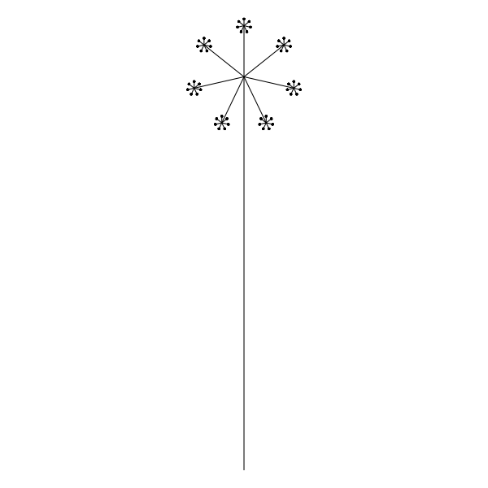

36. The fractal above is composed of many line segments. The largest segment is 1 unit long. There are then 7 segments, each with a length of $k = 0.13$. To continue the pattern, there are 49 segments with length $k^2=0.0169$. Then, 343 segments with length $k^3$ and 2401 with length $k^4$ etc…

    How much total length is needed to construct this fractal (with infinite depths of recursion)? Find the sum of all the lengths.

    In other words, if $k=0.13$, evaluate the following:

    $$\sum_{i=0}^\infty(7k)^{i} ~=~ 1 + 7k + 49k^2 + 343k^3 + \ldots ~=~ ~?$$

    The tolerance is $\pm 0.01$.

#### Solution

#### Question

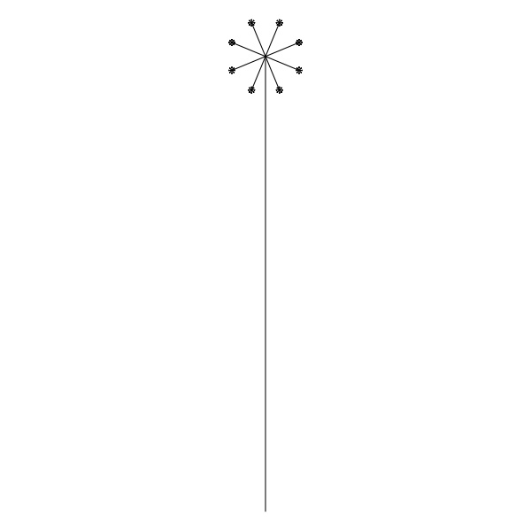

37. The fractal above is composed of many line segments. The largest segment is 1 unit long. There are then 8 segments, each with a length of $k = 0.08$. To continue the pattern, there are 64 segments with length $k^2=0.0064$. Then, 512 segments with length $k^3$ and 4096 with length $k^4$ etc…

    How much total length is needed to construct this fractal (with infinite depths of recursion)? Find the sum of all the lengths.

    In other words, if $k=0.08$, evaluate the following:

    $$\sum_{i=0}^\infty(8k)^{i} ~=~ 1 + 8k + 64k^2 + 512k^3 + \ldots ~=~ ~?$$

    The tolerance is $\pm 0.01$.

#### Solution

#### Question

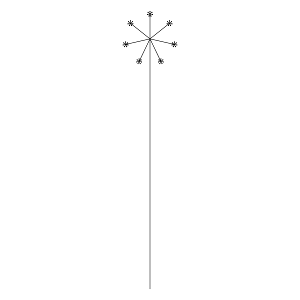

38. The fractal above is composed of many line segments. The largest segment is 1 unit long. There are then 7 segments, each with a length of $k = 0.1$. To continue the pattern, there are 49 segments with length $k^2=0.01$. Then, 343 segments with length $k^3$ and 2401 with length $k^4$ etc…

    How much total length is needed to construct this fractal (with infinite depths of recursion)? Find the sum of all the lengths.

    In other words, if $k=0.1$, evaluate the following:

    $$\sum_{i=0}^\infty(7k)^{i} ~=~ 1 + 7k + 49k^2 + 343k^3 + \ldots ~=~ ~?$$

    The tolerance is $\pm 0.01$.

#### Solution

#### Question

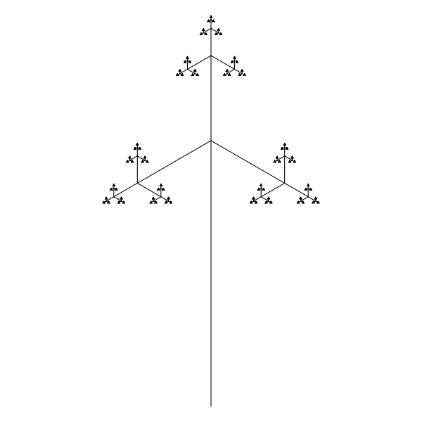

39. The fractal above is composed of many line segments. The largest segment is 1 unit long. There are then 3 segments, each with a length of $k = 0.32$. To continue the pattern, there are 9 segments with length $k^2=0.1024$. Then, 27 segments with length $k^3$ and 81 with length $k^4$ etc…

    How much total length is needed to construct this fractal (with infinite depths of recursion)? Find the sum of all the lengths.

    In other words, if $k=0.32$, evaluate the following:

    $$\sum_{i=0}^\infty(3k)^{i} ~=~ 1 + 3k + 9k^2 + 27k^3 + \ldots ~=~ ~?$$

    The tolerance is $\pm 0.01$.

#### Solution

#### Question

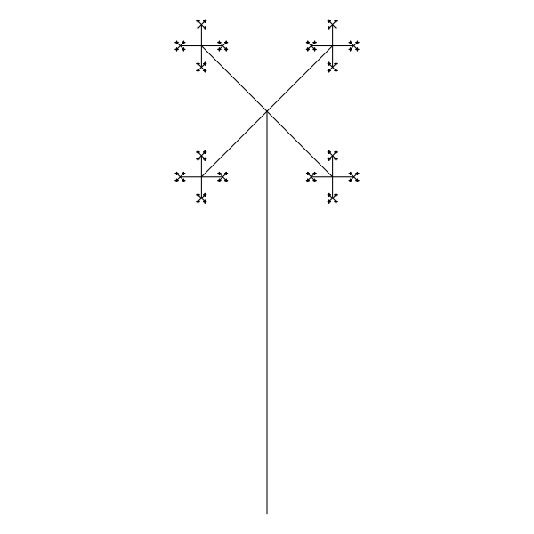

40. The fractal above is composed of many line segments. The largest segment is 1 unit long. There are then 4 segments, each with a length of $k = 0.23$. To continue the pattern, there are 16 segments with length $k^2=0.0529$. Then, 64 segments with length $k^3$ and 256 with length $k^4$ etc…

    How much total length is needed to construct this fractal (with infinite depths of recursion)? Find the sum of all the lengths.

    In other words, if $k=0.23$, evaluate the following:

    $$\sum_{i=0}^\infty(4k)^{i} ~=~ 1 + 4k + 16k^2 + 64k^3 + \ldots ~=~ ~?$$

    The tolerance is $\pm 0.01$.

#### Solution

#### Question

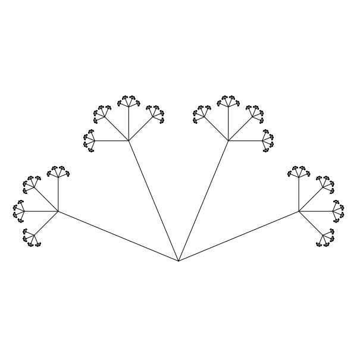

41. The fractal above is composed of many line segments. The largest 4 segments are each 1 unit long. There are then 16 segments, each with a length of $k = 0.26$. To continue the pattern, there are 64 segments with length $k^2=0.0676$. Then, 256 segments with length $k^3$ and 1024 with length $k^4$ etc…

    Is the sum of the lengths finite or infinite?
    1. Finite
    2. Infinite

#### Solution

#### Question

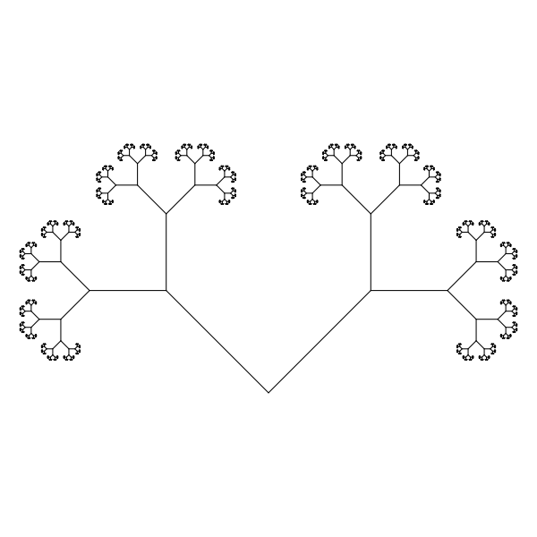

42. The fractal above is composed of many line segments. The largest 2 segments are each 1 unit long. There are then 4 segments, each with a length of $k = 0.53$. To continue the pattern, there are 8 segments with length $k^2=0.2809$. Then, 16 segments with length $k^3$ and 32 with length $k^4$ etc…

    Is the sum of the lengths finite or infinite?
    1. Finite
    2. Infinite

#### Solution

#### Question

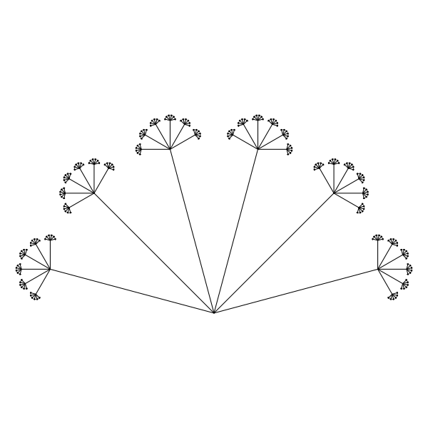

43. The fractal above is composed of many line segments. The largest 6 segments are each 1 unit long. There are then 36 segments, each with a length of $k = 0.17$. To continue the pattern, there are 216 segments with length $k^2=0.0289$. Then, 1296 segments with length $k^3$ and 7776 with length $k^4$ etc…

    Is the sum of the lengths finite or infinite?
    1. Finite
    2. Infinite

#### Solution

#### Question

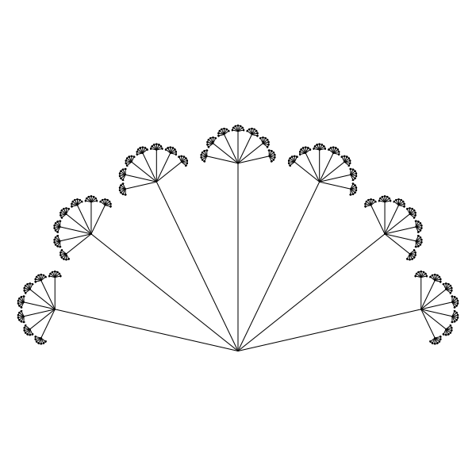

44. The fractal above is composed of many line segments. The largest 7 segments are each 1 unit long. There are then 49 segments, each with a length of $k = 0.17$. To continue the pattern, there are 343 segments with length $k^2=0.0289$. Then, 2401 segments with length $k^3$ and 16807 with length $k^4$ etc…

    Is the sum of the lengths finite or infinite?
    1. Finite
    2. Infinite

#### Solution

#### Question

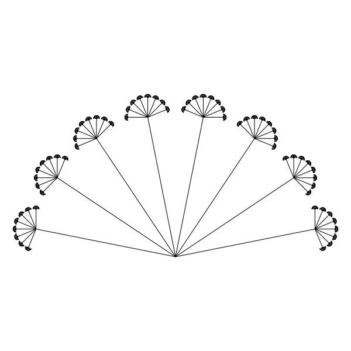

45. The fractal above is composed of many line segments. The largest 8 segments are each 1 unit long. There are then 64 segments, each with a length of $k = 0.14$. To continue the pattern, there are 512 segments with length $k^2=0.0196$. Then, 4096 segments with length $k^3$ and 32768 with length $k^4$ etc…

    Is the sum of the lengths finite or infinite?
    1. Finite
    2. Infinite

#### Solution

#### Question

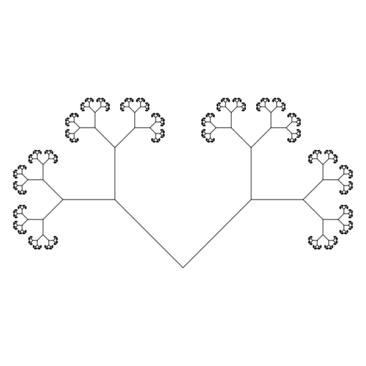

46. The fractal above is composed of many line segments. The largest 2 segments are each 1 unit long. There are then 4 segments, each with a length of $k = 0.54$. To continue the pattern, there are 8 segments with length $k^2=0.2916$. Then, 16 segments with length $k^3$ and 32 with length $k^4$ etc…

    Is the sum of the lengths finite or infinite?
    1. Finite
    2. Infinite

#### Solution

#### Question

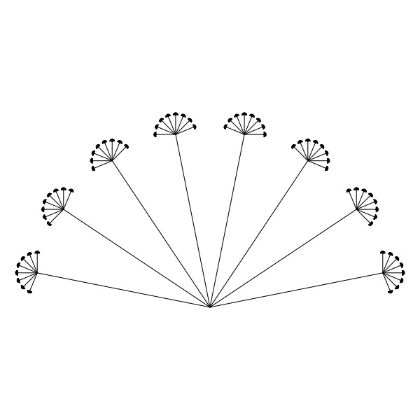

47. The fractal above is composed of many line segments. The largest 8 segments are each 1 unit long. There are then 64 segments, each with a length of $k = 0.11$. To continue the pattern, there are 512 segments with length $k^2=0.0121$. Then, 4096 segments with length $k^3$ and 32768 with length $k^4$ etc…

    Is the sum of the lengths finite or infinite?
    1. Finite
    2. Infinite

#### Solution

#### Question

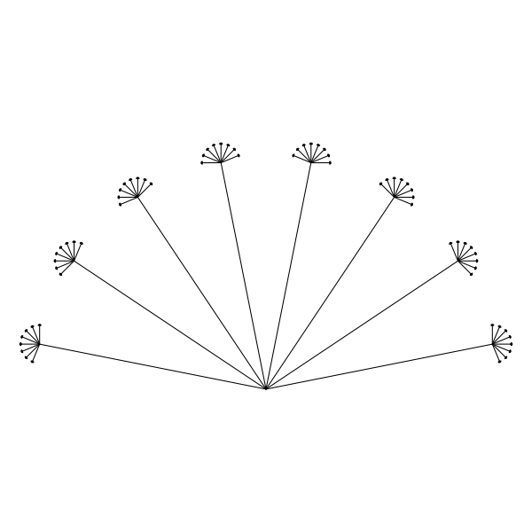

48. The fractal above is composed of many line segments. The largest 8 segments are each 1 unit long. There are then 64 segments, each with a length of $k = 0.08$. To continue the pattern, there are 512 segments with length $k^2=0.0064$. Then, 4096 segments with length $k^3$ and 32768 with length $k^4$ etc…

    Is the sum of the lengths finite or infinite?
    1. Finite
    2. Infinite

#### Solution

#### Question

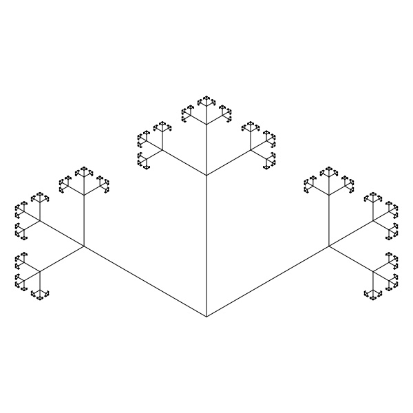

49. The fractal above is composed of many line segments. The largest 3 segments are each 1 unit long. There are then 9 segments, each with a length of $k = 0.36$. To continue the pattern, there are 27 segments with length $k^2=0.1296$. Then, 81 segments with length $k^3$ and 243 with length $k^4$ etc…

    Is the sum of the lengths finite or infinite?
    1. Finite
    2. Infinite

#### Solution

#### Question

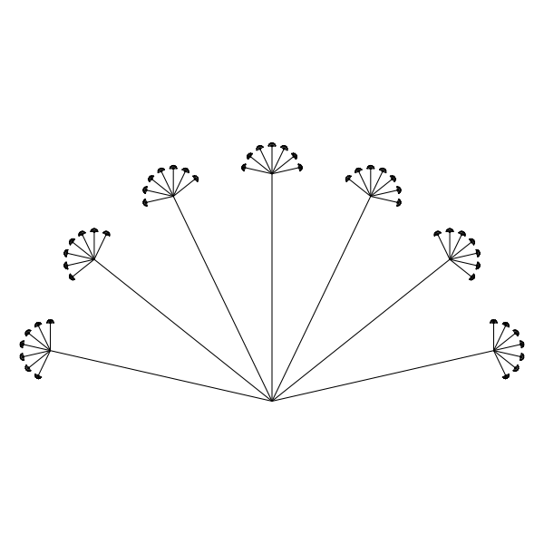

50. The fractal above is composed of many line segments. The largest 7 segments are each 1 unit long. There are then 49 segments, each with a length of $k = 0.12$. To continue the pattern, there are 343 segments with length $k^2=0.0144$. Then, 2401 segments with length $k^3$ and 16807 with length $k^4$ etc…

    Is the sum of the lengths finite or infinite?
    1. Finite
    2. Infinite

#### Solution

#### Question

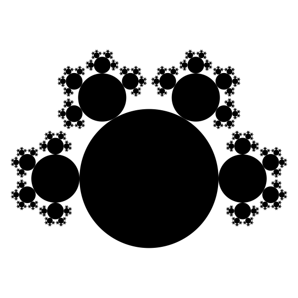

51. A fractal is generated such that the biggest circle has an area of 1 square units. The next generation has 4 circles, each with an area of $k=0.12$ square units. In the next generation of 16 circles, each has an area of $k^2=0.0144$, then 64 circles with area $k^3$ each, etc…

    Find the area of the fractal. The tolerance is $\pm 0.01$.

#### Solution

#### Question

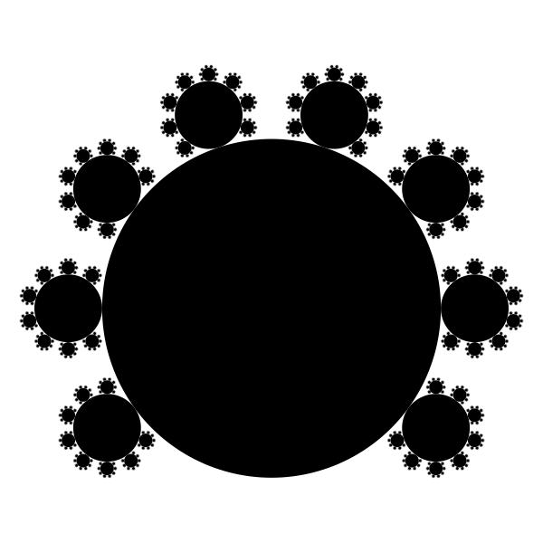

52. A fractal is generated such that the biggest circle has an area of 1 square units. The next generation has 8 circles, each with an area of $k=0.04$ square units. In the next generation of 64 circles, each has an area of $k^2=0.0016$, then 512 circles with area $k^3$ each, etc…

    Find the area of the fractal. The tolerance is $\pm 0.01$.

#### Solution

#### Question

[figure not shown]

53. A fractal is generated such that the biggest circle has an area of 1 square units. The next generation has 3 circles, each with an area of $k=0.06$ square units. In the next generation of 9 circles, each has an area of $k^2=0.0036$, then 27 circles with area $k^3$ each, etc…

    Find the area of the fractal. The tolerance is $\pm 0.01$.

#### Solution

#### Question

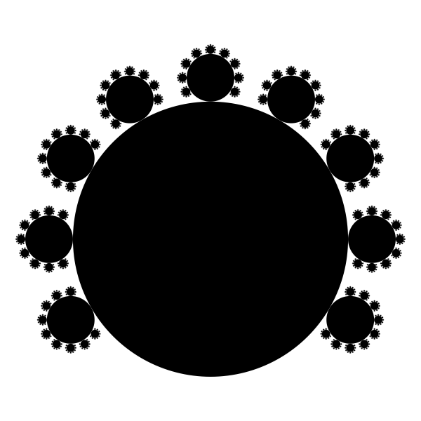

54. A fractal is generated such that the biggest circle has an area of 1 square units. The next generation has 9 circles, each with an area of $k=0.03$ square units. In the next generation of 81 circles, each has an area of $k^2=0.0009$, then 729 circles with area $k^3$ each, etc…

    Find the area of the fractal. The tolerance is $\pm 0.01$.

#### Solution

#### Question

[figure not shown]

55. A fractal is generated such that the biggest circle has an area of 1 square units. The next generation has 3 circles, each with an area of $k=0.18$ square units. In the next generation of 9 circles, each has an area of $k^2=0.0324$, then 27 circles with area $k^3$ each, etc…

    Find the area of the fractal. The tolerance is $\pm 0.01$.

#### Solution

#### Question

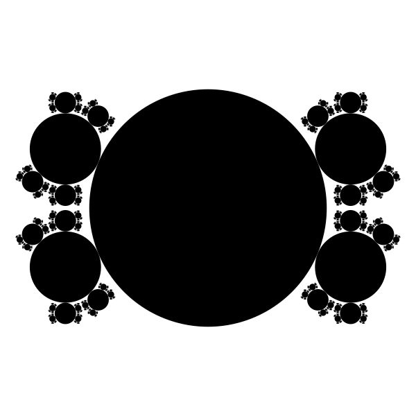

56. A fractal is generated such that the biggest circle has an area of 1 square units. The next generation has 4 circles, each with an area of $k=0.09$ square units. In the next generation of 16 circles, each has an area of $k^2=0.0081$, then 64 circles with area $k^3$ each, etc…

    Find the area of the fractal. The tolerance is $\pm 0.01$.

#### Solution

#### Question

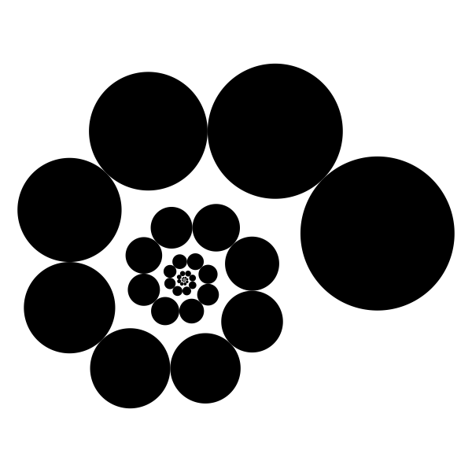

57. A fractal is generated such that the biggest circle has an area of 1 square units. The next generation has 1 circles, each with an area of $k=0.77$ square units. In the next generation of 1 circles, each has an area of $k^2=0.5929$, then 1 circles with area $k^3$ each, etc…

    Find the area of the fractal. The tolerance is $\pm 0.01$.

#### Solution

#### Question

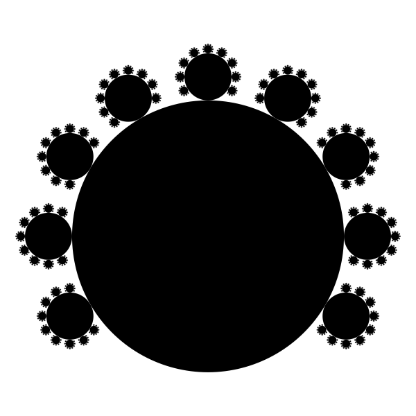

58. A fractal is generated such that the biggest circle has an area of 1 square units. The next generation has 9 circles, each with an area of $k=0.03$ square units. In the next generation of 81 circles, each has an area of $k^2=0.0009$, then 729 circles with area $k^3$ each, etc…

    Find the area of the fractal. The tolerance is $\pm 0.01$.

#### Solution

#### Question

[figure not shown]

59. A fractal is generated such that the biggest circle has an area of 1 square units. The next generation has 4 circles, each with an area of $k=0.09$ square units. In the next generation of 16 circles, each has an area of $k^2=0.0081$, then 64 circles with area $k^3$ each, etc…

    Find the area of the fractal. The tolerance is $\pm 0.01$.

#### Solution

#### Question

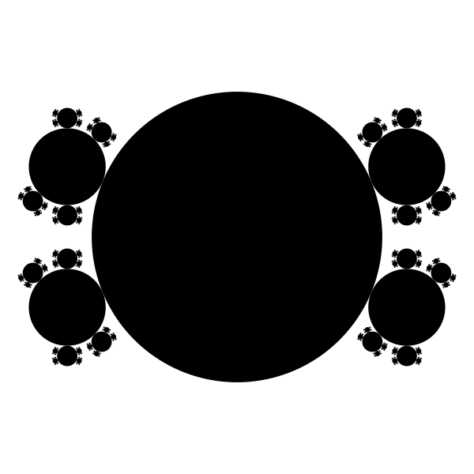

60. A fractal is generated such that the biggest circle has an area of 1 square units. The next generation has 4 circles, each with an area of $k=0.07$ square units. In the next generation of 16 circles, each has an area of $k^2=0.0049$, then 64 circles with area $k^3$ each, etc…

    Find the area of the fractal. The tolerance is $\pm 0.01$.

#### Solution